# Simulation exercises

jagdeep s sihota

The exponential distribution can be simulated in R with rexp(n, lambda) where lambda is the rate parameter. The mean of exponential distribution is 1/lambda and the standard deviation is also also 1/lambda. Set lambda = 0.2 for all of the simulations. In this simulation, We will investigate the distribution of averages of 40 exponential(0.2)s. Note that we will need to do a thousand or so simulated averages of 40 exponentials.

### Simulate the mean of 40 exponential (0.2)s.

```r
n <- 40
nosim <- 1000
lambda <- .2
set.seed(1234)
sample_mean <- replicate(nosim, mean(rexp(n, rate = lambda)))
summary(sample_mean)
```

```
##    Min. 1st Qu.  Median    Mean 3rd Qu.    Max.
##    3.17    4.43    4.94    4.97    5.51    7.39
```

### 1. Show where the distribution is centered at and compare it to the theoretical center of the distribution.

```r
sample_mean_mu <- mean(sample_mean)
theo_mean = 1/lambda
```

**the distribution is centered at 4.9742, the theoretical center of the distribution is 5**

### 2. Show how variable it is and compare it to the theoretical variance of the distribution.

```r
sample_sd <- sd(sample_mean)
sample_var <- (sample_sd)^2
theo_mean = 1/lambda
theo_var<- (1/lambda)^2/n
```

**The variance of the distribution is 0.5707, and the theoretical variance of the distribution is 0.625**

### 3. Show that the distribution is approximately normal.

#### As we can see that the distribution is approximately normal by looking at the histogram below.

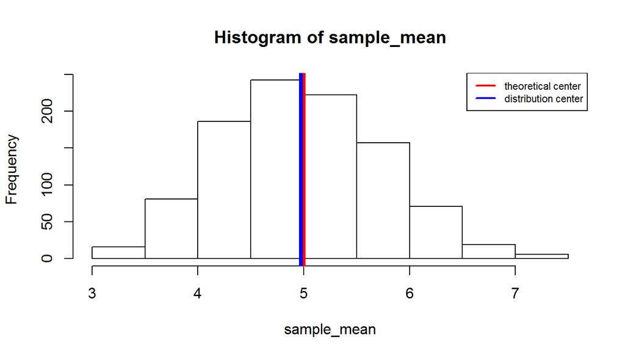

```r
hist(sample_mean)
abline(v=theo_mean, col = "red", lwd = 4)
abline(v=sample_mean_mu, col = "blue", lwd = 4)
legend("topright", lty = 1, lwd = 2, col = c("red", "blue"), legend = c("theoretical center", "distribution center"), cex = .7)
```

### 4. Evaluate the coverage of the confidence interval for 1/lambda

```r
confidence_interval <- sample_mean_mu + c(-1,1) + 1.96 * sample_var/sqrt(n)
```

#### The confidence interval for 1/lambda is 4.1511 to 6.1511